# HymHub: analysis demo

HymHub provides descriptive statistics of several genome features for 13 species in the order Hymenoptera. These summary statistics are stored in tabular format (tab-separated values or TSV) to facilitate loading into popular statistics packages for analysis.

This notebook isn’t designed to do anything particularly useful other than provide a brief demo for loading a data set into an R data frame and pulling data of interest out of that data frame. Here we will focus on interval loci (iLoci), but everything in this demo also applies to the data tables for other genomic features available from HymHub.

## Read data into memory

In R, tabular data is read into memory using the `read.table` function. This creates a data frame object, which we can peek at using the `head` function.

```r
loci <- read.table("iloci.tsv", header=TRUE, sep="\t", stringsAsFactors=FALSE)
head(loci, n=5) # Let's check out the first 5 rows of the data frame
```

```
##   Species                   LocusId Length GCContent GCSkew NContent
## 1    Ador HymHubAdorILCv0.0.1-00001  26624     0.431  0.010    0.082
## 2    Ador HymHubAdorILCv0.0.1-00002  49798     0.411 -0.014    0.084
## 3    Ador HymHubAdorILCv0.0.1-00003   3565     0.344  0.115    0.041
## 4    Ador HymHubAdorILCv0.0.1-00004  17238     0.296 -0.021    0.028
## 5    Ador HymHubAdorILCv0.0.1-00005   6340     0.252  0.011    0.000
##   LocusClass GeneCount SeqUnannot
## 1   geneless         0      False
## 2       mRNA         1      False
## 3   geneless         0      False
## 4       mRNA         1      False
## 5      ncRNA         2      False
```

We can use the `str` command for a more detailed description.

```r
str(loci)
```

```
## 'data.frame':    301165 obs. of  9 variables:
##  $ Species   : chr  "Ador" "Ador" "Ador" "Ador" ...
##  $ LocusId   : chr  "HymHubAdorILCv0.0.1-00001" "HymHubAdorILCv0.0.1-00002" "HymHubAdorILCv0.0.1-00003" "HymHubAdorILCv0.0.1-00004" ...
##  $ Length    : int  26624 49798 3565 17238 6340 31642 80759 17007 137366 1201 ...
##  $ GCContent : num  0.431 0.411 0.344 0.296 0.252 0.288 0.29 0.335 0.319 0.293 ...
##  $ GCSkew    : num  0.01 -0.014 0.115 -0.021 0.011 -0.006 -0.022 -0.002 0.001 -0.028 ...
##  $ NContent  : num  0.082 0.084 0.041 0.028 0 0.045 0.022 0.033 0.04 0 ...
##  $ LocusClass: chr  "geneless" "mRNA" "geneless" "mRNA" ...
##  $ GeneCount : int  0 1 0 1 2 0 1 0 1 0 ...
##  $ SeqUnannot: chr  "False" "False" "False" "False" ...
```

## Get the number of iLoci for each species

iLocus data for all 13 species in HymHub are included in the same table. The **Species** column is provided to help distinguish which species a particular iLocus belongs to (see [this page](http://brendelgroup.github.io/HymHub/genomes.html) for a full description). We can grab the species values and determine how many rows (iLoci) correspond to each species.

```r
loci.rle <- rle(as.vector(loci$Species))
nloci <- data.frame(loci.rle$values, loci.rle$lengths)
colnames(nloci) <- c("Species", "NumLoci")
nloci
```

```
##    Species NumLoci
## 1     Ador   17485
## 2     Aflo   20061
## 3     Amel   18986
## 4     Bimp   18903
## 5     Bter   16943
## 6     Cflo   50104
## 7     Dmel   14440
## 8     Hsal   25599
## 9     Mrot   20621
## 10    Nvit   21885
## 11    Pdom   18875
## 12    Sinv   39858
## 13    Tcas   17405
```

# Plot distribution of iLocus GC content

Here, we discard the 10% most extreme iLoci in terms of length, and then plot the GC content of the remaining iLoci by species.

```r
# Discard extremely short and extremely long iLoci
lq <- quantile(loci$Length, probs=c(0.05, 0.95))
loci.s <- loci[loci$Length > lq[1] & loci$Length < lq[2],]
lq
```

```
##      5%     95%
##   214.0 43090.4
```

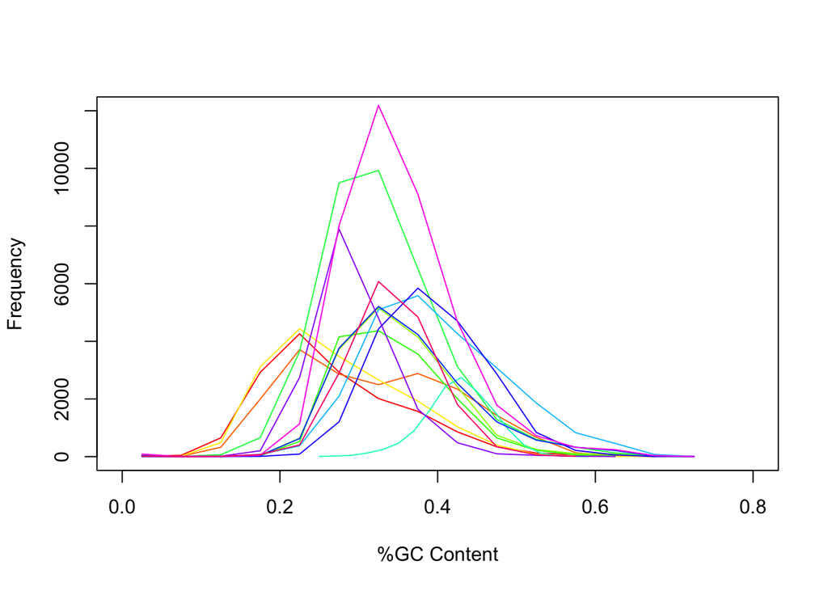

```r
# Grab species list
species <- sort(unique(loci$Species))
nspecies <- length(species)

# Plot histograms as lines
h <- hist(loci.s$GCContent[loci.s$Species == species[1]], plot=FALSE, breaks=20)
plot(h$mids, h$counts, type="l", main="", xlab="%GC Content", ylab="Frequency",
     xlim=c(0, 0.8), ylim=c(0, 12000), col=rainbow(nspecies)[1])
for(i in 2:nspecies)
{
  h <- hist(loci.s$GCContent[loci.s$Species == species[i]], plot=FALSE, breaks=20)
  lines(h$mids, h$counts, col=rainbow(nspecies)[i])
}
```